[figure not shown]

# Parcours Data Analyst

## Projet 7 : Effectuez une prédiction de revenus

### Thomas Dupouy - 07/2018

```r
library(dplyr) # très utile
library(tibble) # pour rownames_to_column
library(plotly) # graphiques
library(jsonlite) # pour les datasources externes
library(reshape2) # pour dcast
library(tidyr) # pour uncount
```

# Mission 1

Résumez les données utilisées :

Année(s) des données utilisées

Nombre de pays présents

Population couverte par l'analyse (en termes de pourcentage de la population mondiale)

```r
setwd("/data/P7/")
Income <- read.csv("world_income_distribution.csv",header=T,stringsAsFactors=FALSE)
key <- sprintf('%s%d%d',Income$country,Income$year_survey,Income$quantile)
cat('Income',nrow(Income),all(duplicated(key)))
cbind(Income %>% head," "='...',Income %>% tail)
```

```
Income 11737 FALSE
```

| country | year_survey | quantile | nb_quantiles | income | pop | gdpppp |  | country | year_survey | quantile | nb_quantiles | income | pop | gdpppp |
| --- | --- | --- | --- | --- | --- | --- | --- | --- | --- | --- | --- | --- | --- | --- |
| ALB | 2008 | 1 | 100 | 728.8980 | 0.03143 | 7297 | ... | COD | 2008 | 95 | 100 | 743.3720 | 0.624749 | 303.1931 |
| ALB | 2008 | 2 | 100 | 916.6623 | 0.03143 | 7297 | ... | COD | 2008 | 96 | 100 | 810.6233 | 0.624749 | 303.1931 |
| ALB | 2008 | 3 | 100 | 1010.9160 | 0.03143 | 7297 | ... | COD | 2008 | 97 | 100 | 911.7834 | 0.624749 | 303.1931 |
| ALB | 2008 | 4 | 100 | 1086.9078 | 0.03143 | 7297 | ... | COD | 2008 | 98 | 100 | 1057.8074 | 0.624749 | 303.1931 |
| ALB | 2008 | 5 | 100 | 1132.6997 | 0.03143 | 7297 | ... | COD | 2008 | 99 | 100 | 1286.6029 | 0.624749 | 303.1931 |
| ALB | 2008 | 6 | 100 | 1171.1412 | 0.03143 | 7297 | ... | COD | 2008 | 100 | 100 | 2243.1226 | 0.624749 | 303.1931 |

# World income distribution 2008

```r
# Pays par année
(Income %>% group_by(Année=year_survey)
 %>% summarise(Pays=length(unique(country)),
               Population=round(sum(pop)))%>% t)

# Données incomplètes
(Income %>% group_by(year_survey,country)
 %>% summarise(quantiles=length(quantile),gdpppp=max(gdpppp))
 %>% filter(is.na(gdpppp) | quantiles!=100))
```

| Année | 2004 | 2006 | 2007 | 2008 | 2009 | 2010 | 2011 |
| --- | --- | --- | --- | --- | --- | --- | --- |
| Pays | 1 | 5 | 15 | 78 | 12 | 6 | 1 |
| Population | 20 | 296 | 6156 | 145940 | 35021 | 388 | 14 |

| year_survey | country | quantiles | gdpppp |
| --- | --- | --- | --- |
| 2008 | CHE | 84 | 38160 |
| 2008 | LTU | 99 | 17571 |
| 2008 | SGP | 54 | 47995 |
| 2008 | XKX | 100 | NA |
| 2009 | PSE | 100 | NA |

```r
Income2008 <- (Income %>% filter(year_survey==2008 & !country%in%c('CHE','LTU','SGP','XKX'))
           %>% select(iso3=country,classe=quantile,revenus=income,pop=pop,gdpppp=gdpppp))
key <- sprintf('%s%d',Income2008$iso3,Income2008$classe)
# cat('Income2008',nrow(Income2008),all(duplicated(key)))
head(Income2008,4)
```

| iso3 | classe | revenus | pop | gdpppp |
| --- | --- | --- | --- | --- |
| ALB | 1 | 728.8980 | 0.03143 | 7297 |
| ALB | 2 | 916.6623 | 0.03143 | 7297 |
| ALB | 3 | 1010.9160 | 0.03143 | 7297 |
| ALB | 4 | 1086.9078 | 0.03143 | 7297 |

```r
cbind(as.data.frame(2008) %>% rename('Année'='2008'),
Income2008 %>% select(iso3) %>% distinct %>% count %>% rename('Pays présents'='n'),
Income2008 %>% summarise('% pop. mondiale'=round(sum(pop)/69297250,3)*100,
'Taille échantillon'=length(iso3)))
```

| Année | Pays présents | % pop. mondiale | Taille échantillon |
| --- | --- | --- | --- |
| 2008 | 74 | 0.2 | 7400 |

```r
data <- Income2008 %>% group_by(iso3) %>% summarise(revenus=round(mean(revenus)))
# specify map projection/options
g <- list(showframe=F,showcoastlines=T,projection=list(type='Mercator'))
l <- list(color=toRGB("grey"), width=0.5)

p <- (plot_geo(data)
      %>% add_trace(z=~revenus,color=~revenus,
                    colors='Reds',text=~iso3,locations=~iso3,marker=list(line=l))
      %>% colorbar(tickprefix='$',title='Revenu annuel moyen')
      %>% layout(geo=g))
plotly_IMAGE(p, format = "png", out_file = "revenu-annuel-moyen.png")
```

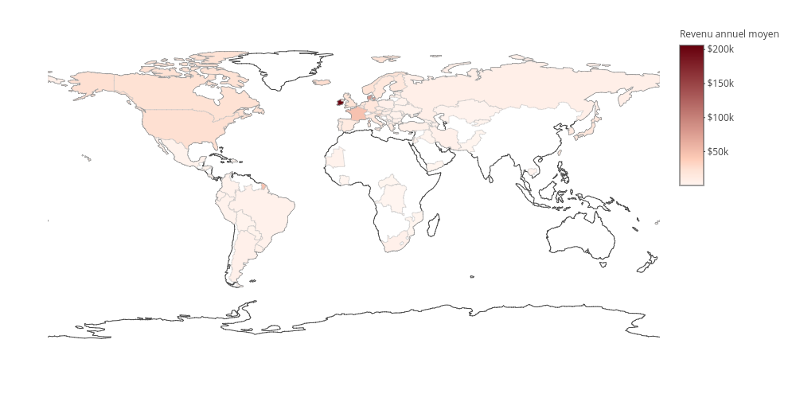

Le **coefficient de Gini** est une mesure statistique de la dispersion d'une distribution dans une population donnée, développée par le statisticien italien Corrado Gini. Le coefficient de Gini est un nombre variant de 0 à 1, où 0 signifie l'égalité parfaite et 1 signifie une inégalité parfaite.

La **méthode EKS (Eltöte-Köves-Szulc)** est une méthode multilatérale développée par O. Elteto, P. Koves et B. Szulc qui calcule la nième racine du produit de tous les indices de Fisher possibles entre n pays.Le principal concurrent de la méthode EKS est la méthode Geary-Khami

**Purchasing Power Parity (PPP)** ou parité de pouvoir d'achat (PPA en français) est un taux de conversion monétaire qui permet d'exprimer dans une unité commune les pouvoirs d'achat des différentes monnaies. Ce taux exprime le rapport entre la quantité d'unités monétaires nécessaire dans des pays différents pour se procurer le même « panier » de biens et de services.

# Données supplémentaires

[figure not shown]

```r
# Données supplémentaires
Countries <- (fromJSON("countries.json",flatten=T)[[2]]
              %>% na.omit
              %>% select(iso3=id,name,region.id,region.name=region.value,income.level=incomeLevel.value))
print('Countries')
head(Countries,4)
```

```
[1] "Countries"
```

| iso3 | name | region.id | region.name | income.level |
| --- | --- | --- | --- | --- |
| ABW | Aruba | LCN | Latin America & Caribbean | High income |
| AFG | Afghanistan | SAS | South Asia | Low income |
| AFR | Africa | NA | Aggregates | Aggregates |
| AGO | Angola | SSF | Sub-Saharan Africa | Lower middle income |

```r
Gini <- (fromJSON("SI.POV.GINI.json",flatten=T)[[2]]
            %>% na.omit
            #%>% filter(date%in%c(2004,2006,2007,2008,2009,2010,2011))
            #%>% filter(date==2008)
            %>% select(iso3=countryiso3code,date,gini=value))
print('Gini')
head(Gini,4)
```

```
[1] "Gini"
```

|  | iso3 | date | gini |
| --- | --- | --- | --- |
| 2790 | ALB | 2012 | 29.0 |
| 2794 | ALB | 2008 | 30.0 |
| 2797 | ALB | 2005 | 30.6 |
| 2800 | ALB | 2002 | 31.7 |

```r
GDIM <- read.csv("GDIMMay2018.csv",header=T)
print('GDIM')
head(GDIM,2)
```

```
[1] "GDIM"
```

| countryname | wbcode | iso3 | region | incgroup2 | incgroup4 | fragile | survey | year | status | ⋯ | Cores2125_MAcatC1 | Shortfall0611_obs | Shortfall0611_IGP | Shortfall1217_obs | Shortfall1217_IGP | IGEincome | S1 | S2 | S3 | MLD_psu |
| --- | --- | --- | --- | --- | --- | --- | --- | --- | --- | --- | --- | --- | --- | --- | --- | --- | --- | --- | --- | --- |
| Afghanistan | AFG | AFG | South Asia | Developing economies | Low income | 1 | NRVA | 1980 | Co-residents only | ⋯ | NA | 25103 | 0.08619742 | 18054 | 0.3452242 | NA | NA | NA | NA | 0.1 |
| Afghanistan | AFG | AFG | South Asia | Developing economies | Low income | 1 | NRVA | 1980 | Co-residents only | ⋯ | NA | 12107 | 0.08327112 | 8538 | 0.3899521 | NA | NA | NA | NA | 0.1 |

Les données de la world income distribution présentent pour chaque pays les quantiles de la distribution des revenus de leur population respective.

De quel type de quantiles s'agit-il (quartiles, déciles, etc.) ?

Échantillonner une population en utilisant des quantiles est-il selon vous une bonne méthode ? Pourquoi ?

[figure not shown]

# Mission 2

Montrez la diversité des pays en termes de distribution de revenus à l'aide d'un graphique.

```r
MyCountries <- Income2008 %>% right_join(Countries %>% filter(iso3%in%c('BOL','PER','ZAF','FRA','USA','SVN')))
MyCountries <- MyCountries %>% mutate(revenus = ifelse(iso3=='FRA' & classe==1, round(revenus/1e3), round(revenus)))
MyCountries <- MyCountries %>% mutate(revenus = ifelse(iso3=='SVN' & classe==1, round(revenus/1e3), round(revenus)))
MyCountries %>% group_by(iso3) %>% filter(row_number() <= 1)
```

| iso3 | classe | revenus | pop | gdpppp | name | region.id | region.name | income.level |
| --- | --- | --- | --- | --- | --- | --- | --- | --- |
| BOL | 1 | 21 | 0.09684093 | 3950 | Bolivia | LCN | Latin America & Caribbean | Lower middle income |
| FRA | 1 | 2958 | 0.64188217 | 30357 | France | ECS | Europe & Central Asia | High income |
| PER | 1 | 173 | 0.28836700 | 7858 | Peru | LCN | Latin America & Caribbean | Upper middle income |
| SVN | 1 | 2815 | 0.02040000 | 27197 | Slovenia | ECS | Europe & Central Asia | High income |
| USA | 1 | 663 | 3.04060000 | 43261 | United States | NAC | North America | High income |
| ZAF | 1 | 60 | 0.48793022 | 9602 | South Africa | SSF | Sub-Saharan Africa | Upper middle income |

```r
p <- plot_ly(type='bar')
#for (i in MyCountries$iso3 %>% unique) {
for (i in c('BOL','ZAF','PER','SVN','FRA','USA')) {
    pays <- MyCountries %>% filter(iso3==i)
    name <- pays %>% select(name) %>% unique
    p <- p %>% add_trace(y=(pays %>% select(revenus) %>% log %>% round(2) %>% unlist), name=name)
}
p <- p %>%  layout(yaxis=list(title='Valeur log10 des revenus'),
                   xaxis=list(title='Quantiles de la population'),
                   title='Diversité des pays en termes de distribution de revenus',
                   barmode='group')
plotly_IMAGE(p, format = "png", out_file = "diversite_pays_distribution_revenus.png")
# TODO : vérifier que la série est cumulative (caractéristique de croissance)
```

[figure not shown]

Représentez la courbe de Lorenz de chacun des pays choisis.

```r
p <- plot_ly(type='scatter', mode='lines')
for (i in MyCountries$iso3 %>% unique) {
    pays <- MyCountries %>% filter(iso3==i)
    name <- pays %>% select(name) %>% unique
    tot <- cumsum(round(pays$revenus*1e2/sum(pays$revenus),2))
    p <- p %>% add_trace(y=(tot %>% unlist), name=name)
}
p <- p %>%  layout(yaxis=list(title='% cumulé des revenus'),
                   xaxis=list(title='Quantiles de la population'),
                   title='Courbe de Lorenz',
                    barmode='group')
plotly_IMAGE(p, format = "png", out_file = "courbe_lorenz.png")
```

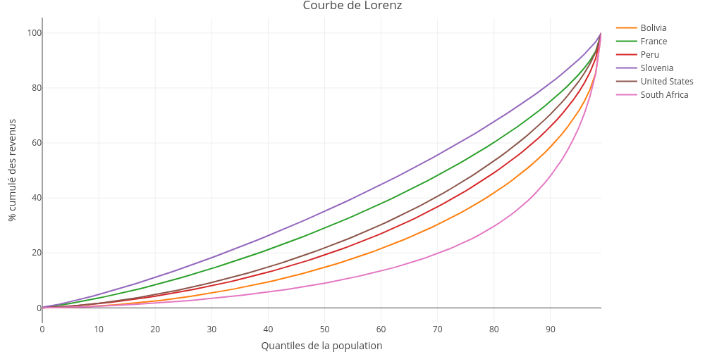

Pour chacun de ces pays, représentez l'évolution de l'indice de Gini au fil des ans.

```r
options(warn=-1)
p <- plot_ly(type = 'scatter', mode = 'lines')

for (i in MyCountries$iso3 %>% unique) {
    pays <- Gini %>% filter(iso3==i & date>2005)
    name <- MyCountries %>% filter(iso3==i) %>% select(name) %>% unique
    p <- p %>% add_trace(x=(pays %>% select(date) %>% unlist),
                         y=(pays %>% select(gini) %>% unlist),
                         name=name)
}
p <- p %>%  layout(yaxis=list(title='Gini'),
                   title="Évolution de l'indice de Gini",
                    barmode='group')
options(warn=0)
plotly_IMAGE(p, format = "png", out_file = "evolution_indice_gini.png")
```

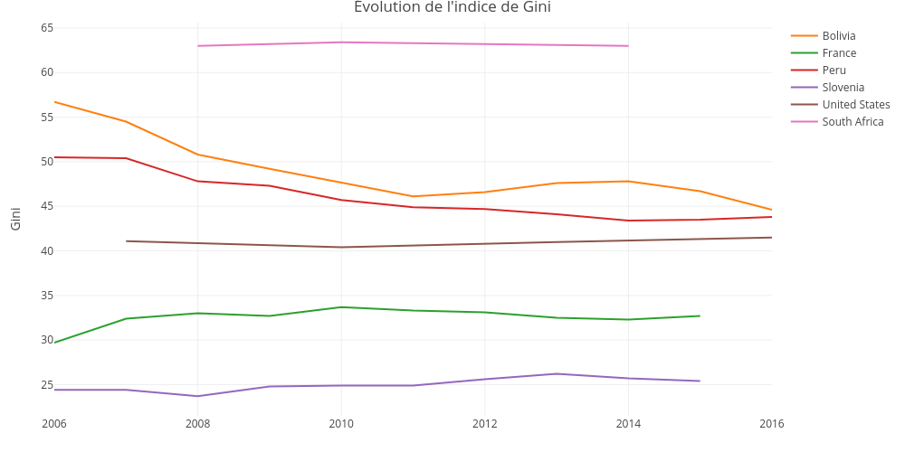

Classez les pays par indice de Gini. Donnez la moyenne, les 5 pays ayant l'indice de Gini le plus élevé et les 5 pays ayant l'indice de Gini le plus faible. En quelle position se trouve la France ?

```r
selection <- Gini %>% filter(date==2008) %>% left_join(Countries,by='iso3') %>% arrange(gini)
selection$pos <- 1:nrow(selection)
selection %>% summarise(Moyenne=round(mean(gini),1))
selection %>% top_n(-5,gini)
selection %>% filter(iso3=='FRA')
selection %>% top_n(5,gini)
```

| Moyenne |
| --- |
| 37 |

| iso3 | date | gini | name | region.id | region.name | income.level | pos |
| --- | --- | --- | --- | --- | --- | --- | --- |
| SVN | 2008 | 23.7 | Slovenia | ECS | Europe & Central Asia | High income | 1 |
| DNK | 2008 | 25.2 | Denmark | ECS | Europe & Central Asia | High income | 2 |
| SVK | 2008 | 26.0 | Slovak Republic | ECS | Europe & Central Asia | High income | 3 |
| CZE | 2008 | 26.3 | Czech Republic | ECS | Europe & Central Asia | High income | 4 |
| UKR | 2008 | 26.6 | Ukraine | ECS | Europe & Central Asia | Lower middle income | 5 |

| iso3 | date | gini | name | region.id | region.name | income.level | pos |
| --- | --- | --- | --- | --- | --- | --- | --- |
| FRA | 2008 | 33 | France | ECS | Europe & Central Asia | High income | 31 |

| iso3 | date | gini | name | region.id | region.name | income.level | pos |
| --- | --- | --- | --- | --- | --- | --- | --- |
| BRA | 2008 | 54.0 | Brazil | LCN | Latin America & Caribbean | Upper middle income | 67 |
| COL | 2008 | 55.4 | Colombia | LCN | Latin America & Caribbean | Upper middle income | 68 |
| HND | 2008 | 55.5 | Honduras | LCN | Latin America & Caribbean | Lower middle income | 69 |
| CAF | 2008 | 56.2 | Central African Republic | SSF | Sub-Saharan Africa | Low income | 70 |
| ZAF | 2008 | 63.0 | South Africa | SSF | Sub-Saharan Africa | Upper middle income | 71 |

# Mission 3

Calculez le coefficient d'élasticité intergénérationnelle.

Sources : GDIM de la World Bank et fichier elasticity.txt

|  | Base case | Optimistic (high mobility) | Pessimistic (low mobility) |  |
| --- | --- | --- | --- | --- |
| Nordic European countries and Canada | 0.2 | 0.15 | 0.3 |  |
| Europe (except nordic countries) | 0.4 | 0.3 | 0.5 |  |
| Australia/New Zealand/USA | 0.4 | 0.3 | 0.5 |  |
| Asia | 0.5 | 0.4 | 0.6 |  |
| Latin America/Africa | 0.66 | 0.5 | 0.9 |  |

```r
# variable globale conservant les distributions conditionnelles
Violette <<- list()

ElasticGirl <- function(pj,nb_quantiles=100) {
    # Cette fonction donne la probabilité de réalisation  par coefficient d'élasticité
    # On arrondi le coefficient à deux digits et on utilise le résultat en cache si déja connu,
    # sinon on le calcule (assez long)
    pj <- round(pj,2)
    idx <- paste0('idx',as.character(pj))
    if (exists(idx,where=Violette)) {
        res <- Violette[[idx]]
    } else {
        # 1. Générez un grand nombre  n de réalisations de la variable variable  ln(Yparent)
        # selon une loi normale. Le choix de la moyenne et de l'écart-type n'auront pas d'incidence sur le résultat
        # final. n doit être supérieur à 1000 fois le nombre de quantiles.
        n <- 1e5
        y_parent <- rnorm(n, mean=5, sd=1) %>% as.data.frame %>% rename('revenus'='.')

        # 2. Générez  n réalisations du terme d'erreur ϵ selon une loi normale de moyenne 0 et d'écart-type 1.
        ϵ <- rnorm(n, mean=0, sd=1)

        # 3. Calculez  ychild=eα+pj*ln(yparent)+ϵ
        # Le choix de α n'a aucune incidence sur le résultat final et peut être supprimé.
        # A ce stade, ychild contient des valeurs dont l'ordre de grandeur ne reflète pas la réalité,
        # mais cela n'a pas d'influence pour la suite.
        ln_y_child <- pj*log(y_parent) + ϵ
        y_child <- exp(ln_y_child)

        # 4. Pour chacun des  n individus générés, calculez la classe de revenu  ci,child ainsi que
        # la classe de revenu de ses parents  ci,parent , à partir de ychild et yparent
        quantiles <- function(Liste) {
            revenus <- sort(Liste[[1]])
            size <- length(revenus)
            classe <- round(seq(1,nb_quantiles+1,nb_quantiles/size) -0.5 + 1./size)[1:size]
            return(data.frame(revenus,classe))}
        c_i_child = quantiles(y_child)
        y_child <- y_child %>% left_join(c_i_child,by='revenus') %>% rename('y_child'='revenus','c_i_child'='classe')
        c_i_parent = quantiles(y_parent)
        y_parent <- y_parent %>% left_join(c_i_parent,by='revenus') %>% rename('y_parent'='revenus','c_i_parent'='classe')
        sample <- data.frame(y_child, y_parent)

        # 5. A partir de cette dernière information, estimez pour chaque ci,child la distribution conditionnelle
        # de ci,parent .
        (res <- (sample
         %>% group_by(c_i_child,c_i_parent)
         %>% count %>% ungroup %>% group_by(c_i_child)
         %>% mutate(prob=n/sum(n)) %>% select(-n)))
        Violette[[idx]] <<- res
        }
    return(res)
}
```

```r
plot_elasticity <- function(country) {
    pj <- GDIM %>% filter(iso3==country & !is.na(IGEincome)) %>% select(IGEincome) %>% distinct %>% as.numeric

    elastic <- ElasticGirl(pj,10)
    out_file = paste("stack", MyCountries %>% filter(iso3==country) %>% select(name) %>% distinct %>% unlist, ".png")
    title <- paste(MyCountries %>% filter(iso3==country) %>% select(name) %>% distinct %>% unlist,
                   "(pj=", round(pj,2),")")
    p <- plot_ly(type = "bar")
    for (i in seq(1,length(elastic$prob))) {
        res <- elastic %>% filter(c_i_child==i)
        p <- p %>% add_trace(x=res$c_i_parent,y=res$prob)
    }
    p <- p %>% layout(yaxis=list(title='Probabilité du quantile enfant'),
                      xaxis=list(title='Quantile parent'),
                      title=title, barmode='stack')
}
```

```r
plot_elasticity('BOL')
```

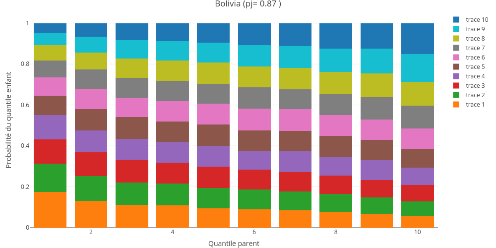

```r
plot_elasticity('FRA')
```

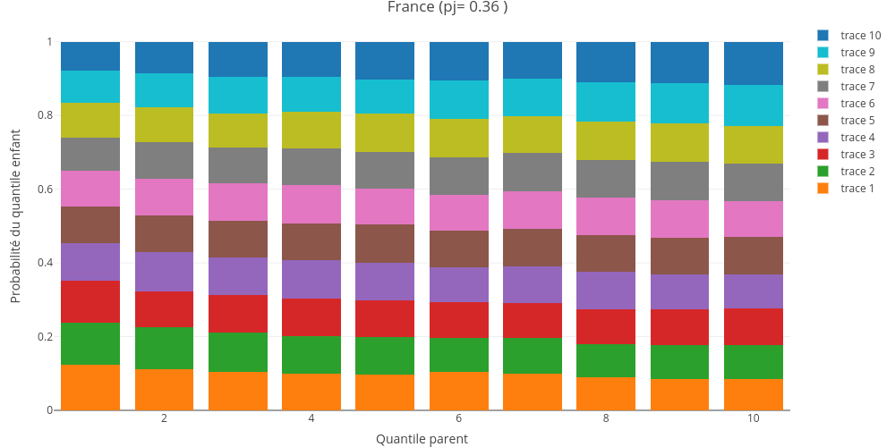

```r
plot_elasticity('PER')
```

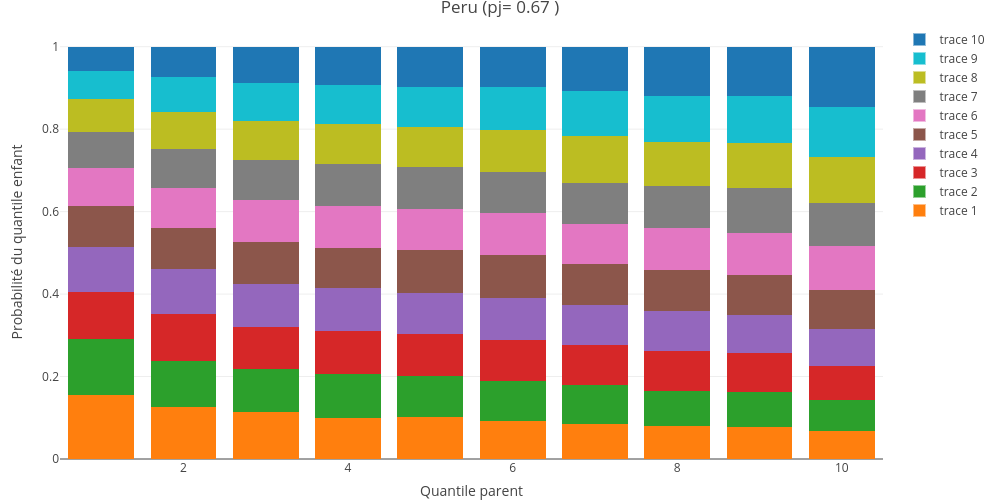

```r
plot_elasticity('KOR')
```

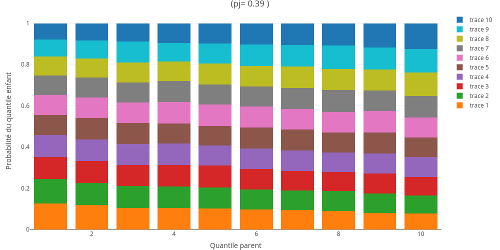

```r
plot_elasticity('USA')
```

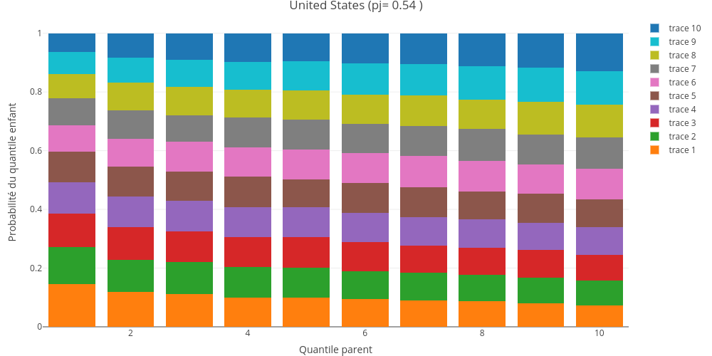

```r
plot_elasticity('ZAF')
```

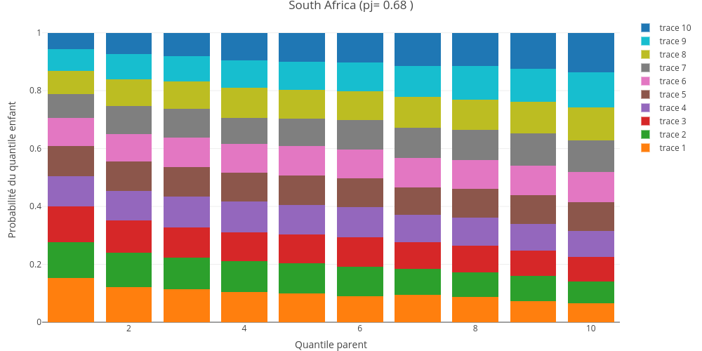

7. Éventuellement et pour éviter toute confusion, effacez les individus que vous venez de générer (nous n'en avons plus besoin), et ne gardez que les distributions conditionnelles.

8. Nous allons maintenant travailler sur un nouvel échantillon. Celui-ci sera créé à partir de la WID. Pour chaque individu de la Wold Income Distribution, créez-en 499 "clones". La taille de votre nouvel échantillon sera donc 500 fois plus grand que celui de la Wold Income Distribution.

9. Pour chaque $c_{i,child}$ et chaque pays, il y a maintenant 500 individus. Vous attribuerez aux 500 individus leurs classes $c_{i,parent}$ conformément aux distributions trouvées précédemment. Par exemple, si $P(c_{i,parent=8}|c_{i,child=5},j)=0.11$ , alors vous assignerez la classe $c_{i,parent=8}$ à 55 des 500 individus du pays j ayant $c_{i,child=5}$ , car $500*0.11 = 55$.

10. Éventuellement et pour éviter toute confusion, effacez la variable $c_{i,child}$: nous n'en avons pas besoin pour la mission 4.

11. Assurez-vous que votre nouvel échantillon contiennent bien les variables initialement présentes dans la World income distribution : $m_j$ et $G_j$.

```r
options(warn=-1)

Violette <<- list() # reset de la variable globale conservant les distributions conditionnelles
# Cette table servira a déterminer la population de chaque tuple (iso3,c_i_child,c_i_parent)

# Cette fonction calcule le nombre d'individus à générer
fillnrows <- function(row) {ElasticGirl(as.numeric(row['pj'])) %>% mutate(iso3=row['iso3'],nrows=round(prob*500))}

# Le résultat est stocké dans un fichier pour réutilisation rapide
destfile <- "M.Indestructible.csv"

if (!file.exists(destfile)) {
    system.time(M.Indestructible <-
            # a partir des codes iso3 de chaque pays
            Income2008 %>% ungroup %>% select(iso3) %>% distinct
            # ajout du coeff d'élasticité
            %>% left_join(GDIM %>% filter(!is.na(IGEincome)) %>% select(iso3,pj=IGEincome)
                                %>% distinct,by='iso3') %>% replace_na(list(pj=0.66))
            # calcul du nombre de lignes à générer
            %>% apply(1,fillnrows) %>% bind_rows %>% na.omit
            # ajout du coeff Gini par pays
            %>% left_join(Gini %>% filter(date==2008) %>% select(iso3,G=gini)
                               %>% distinct,by='iso3') %>% replace_na(list(G=33))
            # ajout du revenu moyen par pays
            %>% left_join(Income2008 %>% group_by(iso3) %>% summarise(m=round(mean(revenus))),by='iso3')
            # ajout du revenu par classe : variable dépendante
            %>% left_join(Income2008 %>% select(iso3,classe,revenus), by=c('iso3'='iso3','c_i_child'='classe'))
            # clonage du nombre d'individus
            %>% uncount(nrows) %>% na.omit
            %>% ungroup %>% select(-c_i_child,-prob)
          )
    write.csv(M.Indestructible,file=destfile,row.names=F)
} else { M.Indestructible <- read.csv(destfile) }

# conversion des variables qualitatives en facteurs
M.Indestructible$iso3 <- as.factor(M.Indestructible$iso3)

options(warn=0)
```

Nous allons maintenant travailler sur un nouvel échantillon. Celui-ci sera créé à partir de la WID. Pour chaque individu de la Wold Income Distribution, créez-en 499 "clones". La taille de votre nouvel échantillon sera donc 500 fois plus grand que celui de la Wold Income Distribution.

```r
paste('M.Indestructible :',length(M.Indestructible$iso3), 'individus')
head(M.Indestructible,3)
summary(M.Indestructible)
```

'M.Indestructible : 3698989 individus'

| c_i_parent | iso3 | G | m | revenus |
| --- | --- | --- | --- | --- |
| 1 | ALB | 30 | 2995 | 728.898 |
| 1 | ALB | 30 | 2995 | 728.898 |
| 1 | ALB | 30 | 2995 | 728.898 |

```
   c_i_parent         iso3               G               m
 Min.   :  1.0   ALB    :  50094   Min.   :23.70   Min.   :   276
 1st Qu.: 26.0   CAN    :  50063   1st Qu.:30.50   1st Qu.:  3278
 Median : 51.0   BOL    :  50058   Median :33.00   Median :  5833
 Mean   : 50.5   LVA    :  50057   Mean   :36.03   Mean   : 12730
 3rd Qu.: 76.0   NLD    :  50057   3rd Qu.:40.40   3rd Qu.: 15228
 Max.   :100.0   PAK    :  50052   Max.   :63.00   Max.   :206138
                 (Other):3398608
    revenus
 Min.   :     17
 1st Qu.:   1709
 Median :   4627
 Mean   :  12723
 3rd Qu.:  11717
 Max.   :5861075
```

```r
# Échantillon
Flèche <- M.Indestructible %>% group_by(iso3) %>% sample_n(500) %>% ungroup %>% arrange(revenus)

# Outliers
Flèche <- Flèche %>% filter(!(abs(revenus - median(revenus)) > 2*sd(revenus)))

# Logarithme
Flèche.log <-  Flèche %>% select(m,revenus) %>% log %>% bind_cols(Flèche %>% select(-m,-revenus))
```

```r
paste('Flèche :',length(Flèche$revenus), 'individus')
summary(Flèche)
```

'Flèche : 36956 individus'

```
   c_i_parent          iso3             G               m
 Min.   :  1.00   ALB    :  500   Min.   :23.70   Min.   :   276
 1st Qu.: 25.00   ARG    :  500   1st Qu.:30.50   1st Qu.:  3278
 Median : 51.00   ARM    :  500   Median :33.00   Median :  5742
 Mean   : 50.62   AUT    :  500   Mean   :36.04   Mean   : 12600
 3rd Qu.: 76.00   AZE    :  500   3rd Qu.:40.40   3rd Qu.: 15228
 Max.   :100.00   BEL    :  500   Max.   :63.00   Max.   :206138
                  (Other):33956
    revenus
 Min.   :    17.32
 1st Qu.:  1709.03
 Median :  4606.76
 Mean   :  8425.66
 3rd Qu.: 11552.43
 Max.   :186732.00
```

```r
p <- (plot_ly(type='histogram')
      %>% add_histogram(x=Flèche$revenus)
      %>% layout(yaxis=list(title='Nombre d\'individus'),
                 xaxis=list(title='Revenus'),
                 showlegend = FALSE,
                 title="Échantillon Flèche"))
```

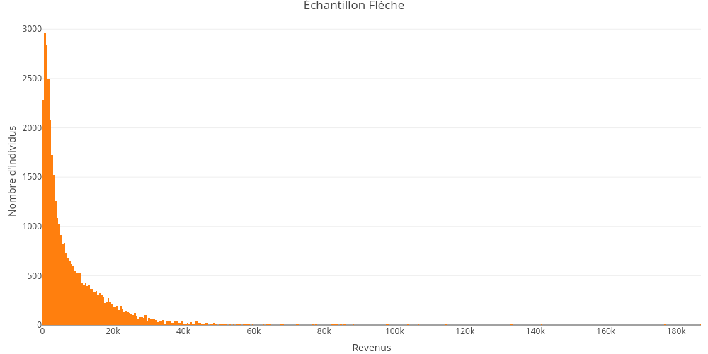

```r
p <- (plot_ly(type='box')
      %>% add_trace(y=Flèche$revenus,name='revenus')
      %>% layout(title="Échantillon Flèche",
                 yaxis=list(title='Revenus'),
                 xaxis=list(title=''),
                 showlegend = FALSE))
plotly_IMAGE(p, format = "png", out_file = "fleche.png")
```

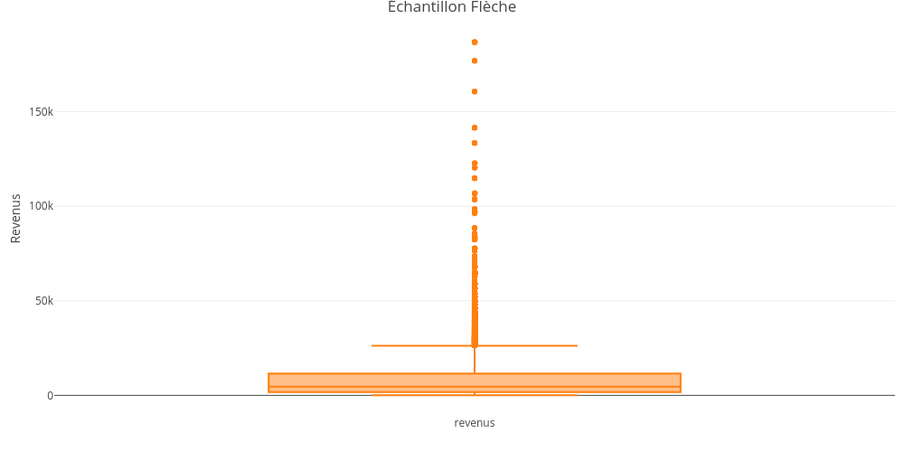

```r
paste('Flèche.log :',length(Flèche.log$revenus), 'individus')
summary(Flèche.log)
```

'Flèche.log : 36956 individus'

```
       m             revenus         c_i_parent          iso3
 Min.   : 5.620   Min.   : 2.852   Min.   :  1.00   ALB    :  500
 1st Qu.: 8.095   1st Qu.: 7.444   1st Qu.: 25.00   ARG    :  500
 Median : 8.656   Median : 8.435   Median : 51.00   ARM    :  500
 Mean   : 8.700   Mean   : 8.335   Mean   : 50.62   AUT    :  500
 3rd Qu.: 9.631   3rd Qu.: 9.355   3rd Qu.: 76.00   AZE    :  500
 Max.   :12.236   Max.   :12.137   Max.   :100.00   BEL    :  500
                                                    (Other):33956
       G
 Min.   :23.70
 1st Qu.:30.50
 Median :33.00
 Mean   :36.04
 3rd Qu.:40.40
 Max.   :63.00
```

```r
p <- (plot_ly(type='histogram')
      %>% add_histogram(x=Flèche.log$revenus)
      %>% layout(showlegend = FALSE,
                 xaxis=list(title='Revenus'),
                 yaxis=list(title='Log. Revenus')
                 title="Flèche.log"))
plotly_IMAGE(p, format = "png", out_file = "fleche.png")
```

[figure not shown]

```r
p <- (plot_ly(type='box')
      %>% add_trace(y=Flèche.log$revenus,name='revenus.log')
      %>% layout(showlegend=F))
plotly_IMAGE(p, format = "png", out_file = "fleche4.png")
```

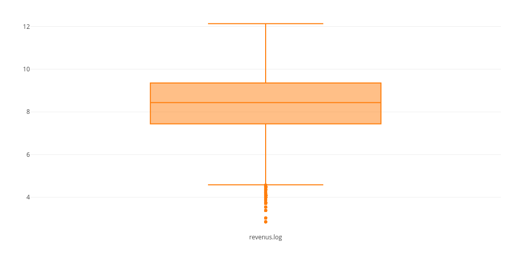

# Mission 4

Appliquez une ANOVA sur vos données, en n’incluant comme variable explicative que le pays de l’individu. Analysez la performance du modèle.

- **SCE** : somme des carrés expliqués. Exprime la variabilité expliquée, à savoir la variation que le facteur explique
- **SCR** : somme des carrés résiduels. Exprime la variabilité résiduelle, à savoir la variation que le facteur n ’arrive pas à expliquer
- **SCT** : somme des carrés totaux. Exprime la variabilité totale des observations
- **$R^2$** : coefficient de détermination. Mesure de la qualité de la prédiction d'une régression linéaire.
- **Distance de Cook** : points méritant un examen plus approfondi dans l'analyse.

Hypothèse H0 : le revenu moyen par centile est identique pour chaque pays.

```r
# revenus est la variable numérique et iso3 indique les groupes
fit <- aov(revenus ~ iso3, data=Flèche.log)
res <- anova(fit)
res1 <- res %>% colSums %>% t %>% setNames(res)
row.names(res1) = "Total"
rbind(res,res1) %>% round(2)
```

|  | Df | Sum Sq | Mean Sq | F value | Pr(>F) |
| --- | --- | --- | --- | --- | --- |
| iso3 | 73 | 44416.34 | 608.44 | 1162.09 | 0 |
| Residuals | 36882 | 19310.48 | 0.52 | NA | NA |
| Total | 36955 | 63726.82 | 608.97 | NA | NA |

```r
options(warn=-1)

p <- plot_ly(ggplot2::diamonds, y = ~MyCountries$revenus, color = ~MyCountries$iso3, type = "box")
plotly_IMAGE(p, format = "png", out_file = "M41.png")
options(warn=0)
```

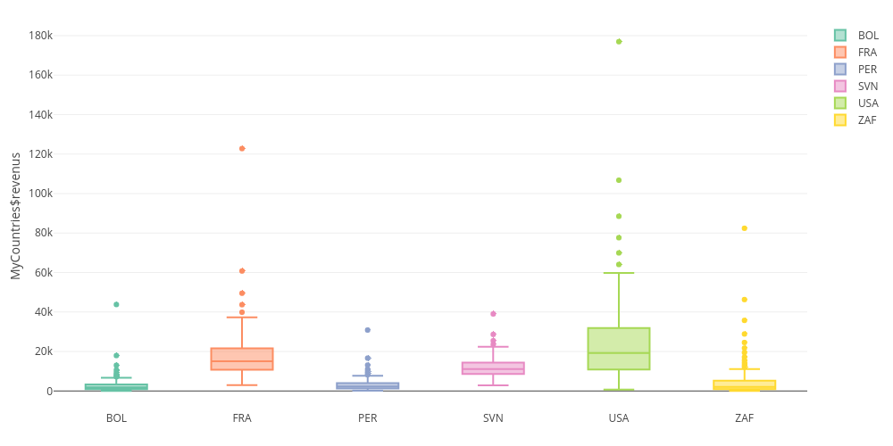

La proba pr(>F) est inférieure au risque de première espèce de 5% donc on rejette H0 : le facteur 'pays' a une influence sur le revenu moyen par centile.

Appliquez une régression linéaire sur vos données, en n’incluant comme variables explicatives uniquement le revenu salaire moyen du pays de l’individu et l’indice de Gini du pays de l’individu. Quel est le pourcentage de variance expliqué par votre modèle ?

```r
fit <- lm(revenus ~ m+G,data=Flèche)
fit.s <- summary(fit)
paste(fit.s$call[3],fit.s$call[2])
paste(round(fit.s$r.squared*100),'% de variance expliquée')
fit.s$coefficients %>% round(2)
```

'Flèche revenus ~ m + G'

'13 % de variance expliquée'

|  | Estimate | Std. Error | t value | Pr(>\|t\|) |
| --- | --- | --- | --- | --- |
| (Intercept) | 15249.34 | 241.12 | 63.24 | 0 |
| m | 0.12 | 0.00 | 54.57 | 0 |
| G | -230.12 | 6.31 | -36.46 | 0 |

```r
fit.log <- lm(revenus ~ m+G,data=Flèche.log)
fit.log.s <- summary(fit.log)
paste(fit.log.s$call[3],fit.log.s$call[2])
paste(round(fit.log.s$r.squared*100),'% de variance expliquée')
fit.log.s$coefficients %>% round(2)
```

'Flèche.log revenus ~ m + G'

'63 % de variance expliquée'

|  | Estimate | Std. Error | t value | Pr(>\|t\|) |
| --- | --- | --- | --- | --- |
| (Intercept) | 1.64 | 0.04 | 37.39 | 0 |
| m | 0.84 | 0.00 | 219.37 | 0 |
| G | -0.02 | 0.00 | -31.95 | 0 |

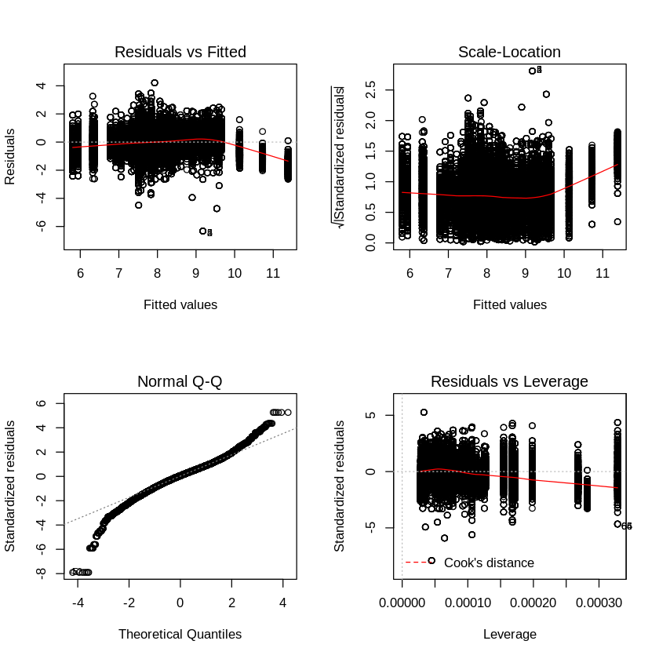

```r
layout(matrix(1:4,2,2))
plot(fit.log)
```

```r
# test de normalité des résidus <-> rejet de H0
ks.test(residuals(fit.log),rnorm)
```

```
	One-sample Kolmogorov-Smirnov test

data:  residuals(fit.log)
D = 4.4958, p-value < 2.2e-16
alternative hypothesis: two-sided
```

Selon ce modèle, donnez la décomposition de variance totale expliquée par :

Le pays de naissance (ie. le revenu moyen et l’indice de Gini)

D’autres facteurs (efforts, chance, etc.)

```r
print('Flèche')
res <- (anova(fit)
 %>% rename(Sum.Sq='Sum Sq',Mean.Sq='Mean Sq',F.value='F value')
 %>% mutate('SC %'=Sum.Sq*100/sum(Sum.Sq))
 %>% round(2)
 )
rownames(res) <- c('m','G','Résidus')
res1 <- res %>% colSums %>% t %>% setNames(res)
row.names(res1) = "Total"
rbind(res,res1) %>% round(2)
```

```
[1] "Flèche"
```

|  | Df | Sum.Sq | Mean.Sq | F.value | Pr(>F) | SC % |
| --- | --- | --- | --- | --- | --- | --- |
| m | 1 | 4.360520e+11 | 436052038705 | 4224.27 | 0 | 9.94 |
| G | 1 | 1.372488e+11 | 137248804864 | 1329.60 | 0 | 3.13 |
| Résidus | 36953 | 3.814485e+12 | 103225319 | NA | NA | 86.93 |
| Total | 36955 | 4.387786e+12 | 573404068889 | NA | NA | 100.00 |

```r
print('Flèche.log')
res <- (anova(fit.log)
 %>% rename(Sum.Sq='Sum Sq',Mean.Sq='Mean Sq',F.value='F value')
 %>% mutate('SC %'=Sum.Sq*100/sum(Sum.Sq))
 %>% round(2)
 )
rownames(res) <- c('m','G','Résidus')
res1 <- res %>% colSums %>% t %>% setNames(res)
row.names(res1) = "Total"
rbind(res,res1) %>% round(2)
```

```
[1] "Flèche.log"
```

|  | Df | Sum.Sq | Mean.Sq | F.value | Pr(>F) | SC % |
| --- | --- | --- | --- | --- | --- | --- |
| m | 1 | 39391.14 | 39391.14 | 61466.95 | 0 | 61.81 |
| G | 1 | 654.32 | 654.32 | 1021.01 | 0 | 1.03 |
| Résidus | 36953 | 23681.36 | 0.64 | NA | NA | 37.16 |
| Total | 36955 | 63726.82 | 40046.10 | NA | NA | 100.00 |

Améliorez le modèle précédent en incluant maintenant la classe de revenu des parents. Quel est le pourcentage de variance expliquée par ce nouveau modèle ?

```r
fit.log <- lm(revenus ~ m+G+c_i_parent,data=Flèche.log)
fit.log.s <- summary(fit.log)
paste(fit.log.s$call[3],fit.log.s$call[2])
paste(round(fit.log.s$r.squared*100),'% de variance expliquée')
fit.log.s$coefficients %>% round(2)
```

'Flèche.log revenus ~ m + G + c_i_parent'

'63 % de variance expliquée'

|  | Estimate | Std. Error | t value | Pr(>\|t\|) |
| --- | --- | --- | --- | --- |
| (Intercept) | 1.51 | 0.04 | 34.22 | 0 |
| m | 0.84 | 0.00 | 220.22 | 0 |
| G | -0.02 | 0.00 | -32.11 | 0 |
| c_i_parent | 0.00 | 0.00 | 17.67 | 0 |

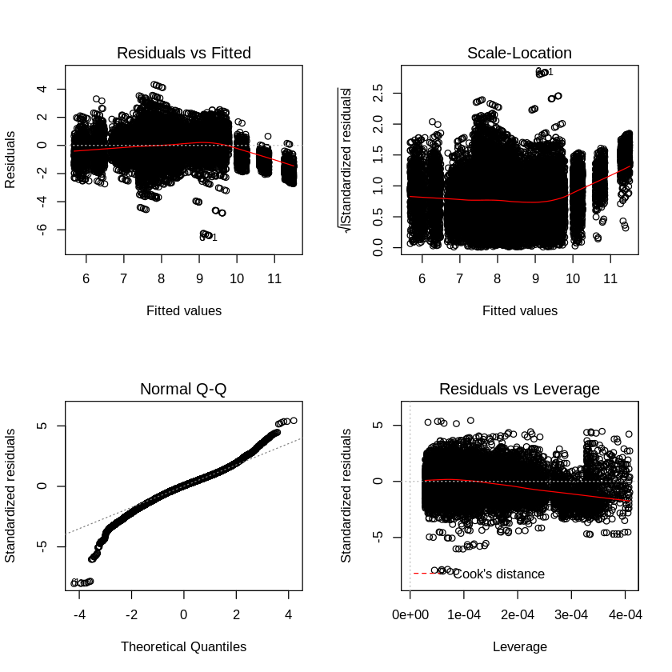

```r
layout(matrix(1:4,2,2))
plot(fit.log)
```

Selon ce dernier modèle, donnez la décomposition de variance totale expliquée par :

Le pays de naissance et le revenu des parents

D’autres facteurs (efforts, chance, etc.)

```r
res <- (anova(fit.log)
 %>% rename(Sum.Sq='Sum Sq',Mean.Sq='Mean Sq',F.value='F value')
 %>% mutate('SC %'=Sum.Sq*100/sum(Sum.Sq))
 %>% round(2)
 )
rownames(res) <- c('m','G','c_i_parent','Résidus')
res1 <- res %>% colSums %>% t %>% setNames(res)
row.names(res1) = "Total"
rbind(res,res1) %>% round(2)
```

|  | Df | Sum.Sq | Mean.Sq | F.value | Pr(>F) | SC % |
| --- | --- | --- | --- | --- | --- | --- |
| m | 1 | 39391.14 | 39391.14 | 61984.87 | 0 | 61.81 |
| G | 1 | 654.32 | 654.32 | 1029.62 | 0 | 1.03 |
| c_i_parent | 1 | 198.51 | 198.51 | 312.37 | 0 | 0.31 |
| Résidus | 36952 | 23482.85 | 0.64 | NA | NA | 36.85 |
| Total | 36955 | 63726.82 | 40244.61 | NA | NA | 100.00 |

En observant le coefficient de régression associé à l’indice de Gini, peut-on affirmer que le fait de vivre dans un pays plus inégalitaire favorise plus de personnes qu’il n’en défavorise ?

```r
res <- fit.log$model %>% unique %>% arrange(G)
coeffG <- coef(fit.log)['G']
itc <- coef(fit.log)['(Intercept)'] + 8
xmin <- min(Flèche.log$G) - .1
xmax <- max(Flèche.log$G) + .1
p <- (plot_ly(x = Flèche.log$G)
      %>% add_markers(y = Flèche.log$revenus)
      %>% add_lines(x=c(xmin,xmax),
                  y=c(coeffG * xmin + itc,coeffG * xmax + itc))

      %>% layout(showlegend = FALSE,
                 xaxis=list(title='Coefficient GINI'),
                 yaxis=list(title='Logarithme des revenus'),
           title=paste0("Régression linéaire des revenus par coefficient de Gini (coeff: ",round(coeffG,2),")")))
plotly_IMAGE(p, format = "png", out_file = "M42.png")
```

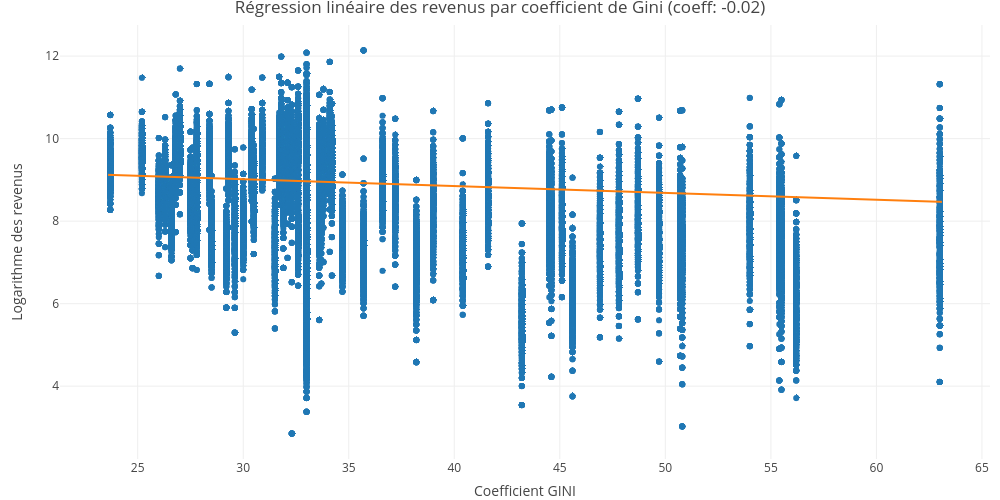

[figure not shown]